# Getting started with mverse

## Simple Example: Transform and Summarise One Numeric Column

Suppose that we have a column `col1` that we wish to transform in three different ways and compute the five number summary of the column after the transformations.

```r
library(mverse)
library(tibble)
library(dplyr)
```

```r
library(ggplot2)
set.seed(6)
df <- tibble(col1 = rnorm(5, 0, 1), col2 = col1 + runif(5))
```

### Step 1: `create_multiverse` of the data frame

```r
mv <- create_multiverse(df)
```

### Step 2: `mutate_branch` to transform `col1`

```r
# Step 2: create a branch - each branch corresponds to a universe

transformation_branch <- mutate_branch(col1 = col1,
                                       col1_t1 = log(abs(col1 + 1)),
                                       col1_t2 = abs(col1))
```

### Step 3: `add_mutate_branch` to `mv`

```r
mv <- mv |> add_mutate_branch(transformation_branch)
```

### Step 4: `execute_multiverse` to execute the transformations

```r
mv <- execute_multiverse(mv)
```

### Step 5: Extract Transformed Values from `mv`

`extract` to add the column to `df_transformed` that labels transformations.

```r
df_transformed <- extract(mv)

df_transformed |> head()
```

```
## # A tibble: 6 × 3
##   universe transformation_branch transformation_branch_branch
##   <fct>                    <dbl> <fct>
## 1 1                       0.270  col1
## 2 1                      -0.630  col1
## 3 1                       0.869  col1
## 4 1                       1.73   col1
## 5 1                       0.0242 col1
## 6 2                       0.239  col1_t1
```

### Step 5: use `tidyverse` to compute the summary and plot the distribution of each transformation (universe)

```r
df_transformed |>
  group_by(transformation_branch_branch) |>
  summarise(n = n(),
            mean = mean(transformation_branch),
            sd = sd(transformation_branch),
            median = median(transformation_branch),
            IQR = IQR(transformation_branch))
```

```
## # A tibble: 3 × 6
##   transformation_branch_branch     n  mean    sd median   IQR
##   <fct>                        <int> <dbl> <dbl>  <dbl> <dbl>
## 1 col1                             5 0.452 0.893  0.270 0.844
## 2 col1_t1                          5 0.179 0.755  0.239 0.601
## 3 col1_t2                          5 0.704 0.658  0.630 0.599
```

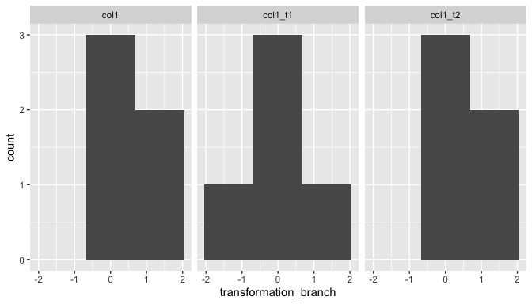

```r
df_transformed |>
  ggplot(aes(x = transformation_branch)) + geom_histogram(bins = 3) +
  facet_wrap(vars(transformation_branch_branch))
```

## Simple Example: Using `mverse` to Fit Three Simple Linear Regression of a Transformed Column

### Step 1: `create_multiverse` of the data frame

```r
mv1 <- create_multiverse(df)
```

### Step 2: Create `formula_branch` of the linear regression models

```r
formulas <- formula_branch(col2 ~ col1,
                           col2 ~ log(abs(col1 + 1)),
                           col2 ~ abs(col1))
```

### Step 3: `add_formula_branch` to multiverse of data frame

```r
mv1 <- mv1 |> add_formula_branch(formulas)
```

### Step 3: `lm_mverse` to compute linear regression models across the multiverse

```r
lm_mverse(mv1)
```

### Step 4: Use `summary` to extract regression output

```r
summary(mv1)
```

```
## # A tibble: 6 × 10
##   universe formulas_branch term    estimate std.error statistic p.value conf.low
##   <fct>    <fct>           <chr>      <dbl>     <dbl>     <dbl>   <dbl>    <dbl>
## 1 1        formulas_1      (Inter…    0.689     0.109      6.31 0.00803   0.342
## 2 1        formulas_1      col1       0.680     0.119      5.71 0.0106    0.301
## 3 2        formulas_2      (Inter…    0.863     0.159      5.43 0.0122    0.358
## 4 2        formulas_2      log(ab…    0.741     0.227      3.26 0.0471    0.0178
## 5 3        formulas_3      (Inter…    0.479     0.330      1.45 0.243    -0.573
## 6 3        formulas_3      abs(co…    0.734     0.360      2.04 0.134    -0.412
## # ℹ 2 more variables: conf.high <dbl>, formulas_branch_code <fct>
```

Let’s compare using `mverse` to using `tidyverse` and base R to fit the three models.

One way to do this using `tidyverse` is to create a list of the model formulas then map the list to `lm`.

```r
mod1 <- formula(col2 ~ col1)

mod2 <- formula(col2 ~ log(abs(col1 + 1)))

mod3 <- formula(col2 ~ abs(col1))

models <- list(mod1, mod2, mod3)

models |>
  purrr::map(lm, data = df) |>
  purrr::map(broom::tidy) |>
  bind_rows()
```

```
## # A tibble: 6 × 5
##   term               estimate std.error statistic p.value
##   <chr>                 <dbl>     <dbl>     <dbl>   <dbl>
## 1 (Intercept)           0.689     0.109      6.31 0.00803
## 2 col1                  0.680     0.119      5.71 0.0106
## 3 (Intercept)           0.863     0.159      5.43 0.0122
## 4 log(abs(col1 + 1))    0.741     0.227      3.26 0.0471
## 5 (Intercept)           0.479     0.330      1.45 0.243
## 6 abs(col1)             0.734     0.360      2.04 0.134
```

```r
modfit <- lapply(models, function(x) lm(x, data = df))

lapply(modfit, function(x) summary(x)[4])
## [[1]]
## [[1]]$coefficients
##              Estimate Std. Error  t value    Pr(>|t|)
## (Intercept) 0.6888352  0.1090963 6.314013 0.008029051
## col1        0.6795288  0.1189216 5.714092 0.010634165
##
##
## [[2]]
## [[2]]$coefficients
##                     Estimate Std. Error  t value   Pr(>|t|)
## (Intercept)        0.8630266  0.1588415 5.433258 0.01223797
## log(abs(col1 + 1)) 0.7409497  0.2272193 3.260945 0.04709792
##
##
## [[3]]
## [[3]]$coefficients
##              Estimate Std. Error  t value  Pr(>|t|)
## (Intercept) 0.4789365  0.3303897 1.449611 0.2430335
## abs(col1)   0.7344512  0.3601450 2.039321 0.1341343
```

## Are Soccer Referees Biased?

In this example, we use a real dataset that demonstrates how `mverse` makes it easy to define multiple definitions for a column and compare the results of the different definitions. We combine soccer player skin colour ratings by two independent raters (`rater1` and `rater2`) from `soccer` dataset included in `mverse`.

The data comes from Silberzahn et al. (2014) and contains 146,028 rows of player-referee pairs. For each player, two independent raters coded their skin tones on a 5-point scale ranging from *very light skin* (`0.0`) to *very dark skin* (`1.0`). For the purpose of demonstration, we only use a unique record per player and consider only those with both ratings.

```r
library(mverse)
soccer_bias <- soccer[!is.na(soccer$rater1) & !is.na(soccer$rater2),
                      c("playerShort", "rater1", "rater2")]
soccer_bias <- unique(soccer_bias)
head(soccer_bias)
```

```
##          playerShort rater1 rater2
## 1      lucas-wilchez   0.25   0.50
## 2         john-utaka   0.75   0.75
## 6       aaron-hughes   0.25   0.00
## 7 aleksandar-kolarov   0.00   0.25
## 8   alexander-tettey   1.00   1.00
## 9  anders-lindegaard   0.25   0.25
```

We would like to study the distribution of the player skin tones but the two independent rating do not always match. To combine the two ratings, we may choose to consider the following options:

1. the mean numeric value
2. the darker rating of the two
3. the lighter rating of the two
4. the first rating only
5. the second rating only

## Analysis using Base R and `Tidyverse`

Let’s first consider how you might study the five options using R without `mverse`. First, we define the five options as separate variables in R.

```r
skin_option_1 <- (soccer_bias$rater1 + soccer_bias$rater2) / 2
skin_option_2 <- ifelse(soccer_bias$rater1 > soccer_bias$rater2,
                        soccer_bias$rater1,
                        soccer_bias$rater2)
skin_option_3 <- ifelse(soccer_bias$rater1 < soccer_bias$rater2,
                        soccer_bias$rater1,
                        soccer_bias$rater2)
skin_option_4 <- soccer_bias$rater1
skin_option_5 <- soccer_bias$rater2
```

We can plot a histogram to study the distribution of the resulting skin tone value for each option. Below is the histogram for the first option (`skin_option_1`).

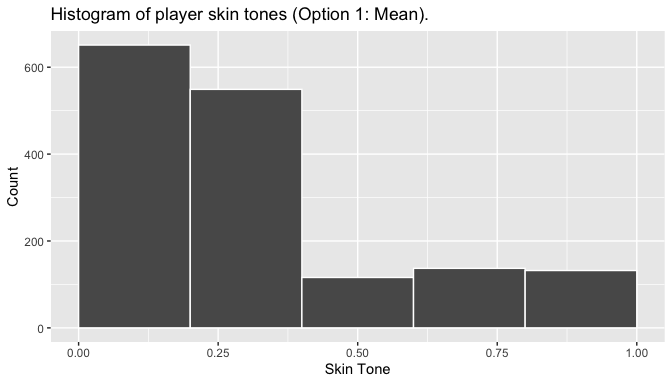

```r
library(ggplot2)
ggplot(mapping = aes(x = skin_option_1)) +
  geom_histogram(breaks = seq(0, 1, 0.2),
                 colour = "white") +
  labs(title = "Histogram of player skin tones (Option 1: Mean).",
       x = "Skin Tone", y = "Count")
```

For the remaining four options, we can repeat the step above to examine the distributions, or create a new data frame combining all five options to use in a ggplot as shown below. In both cases, users need to take care of plotting all five manually.

[figure not shown]

```r
skin_option_all <- data.frame(
  x = c(skin_option_1,
        skin_option_2,
        skin_option_3,
        skin_option_4,
        skin_option_5),
  Option = rep(
    c("Option 1: Mean",
      "Option 2: Max",
      "Option 3: Min",
      "Option 4: Rater 1",
      "Option 5: Rater 2"),
    each = nrow(df)
  )
)
ggplot(data = skin_option_all) +
  geom_histogram(aes(x = x), binwidth = 0.1) +
  labs(title = "Histogram of player skin tones for each option.",
       x = "Skin Tone", y = "Count") +
  facet_wrap(. ~ Option)
```

## Analysis Using `mverse`

### Branching Using `mverse`

We now turn to `mverse` to create the five options above. First, we define an `mverse` object with the dataset. Note that `mverse` assumes a single dataset for each multiverse analysis.

```r
soccer_bias_mv <- create_multiverse(soccer_bias)
```

A *branch* in `mverse` refers to different modelling or data wrangling decisions. For example, a mutate branch - analogous to `mutate` method in `tidyverse`’s data manipulation grammar, lets you define a set of options for defining a new column in your dataset.

You can create a mutate branch with `mutate_branch()`. The syntax for defining the options inside `mutate_branch()` follows the `tidyverse`’s grammar as well.

```r
skin_tone <- mutate_branch(
  (rater1 + rater2) / 2,
  ifelse(rater1 > rater2, rater1, rater2),
  ifelse(rater1 < rater2, rater1, rater2),
  rater1,
  rater2
)
```

Then add the newly defined mutate branch to the `mv` object using `add_mutate_branch()`.

```r
soccer_bias_mv <- soccer_bias_mv |> add_mutate_branch(skin_tone)
```

Adding a branch to a `mverse` object multiplies the number of environments defined inside the object so that the environments capture all unique analysis paths. Without any branches, a `mverse` object has a single environment. We call these environments *universes*. For example, adding the `skin_tone` mutate branch to `mv` results in $1 \times 5 = 5$ universes inside `mv`. In each universe, the analysis dataset now has a new column named `skin_tone` - the name of the mutate branch object.

You can check that the mutate branch was added with `summary()` method for the `mv` object. The method prints a *multiverse table* that lists all universes with branches as columns and corresponding options as values defined in the `mv` object.

```r
summary(soccer_bias_mv)
```

```
## # A tibble: 5 × 3
##   universe skin_tone_branch skin_tone_branch_code
##   <fct>    <fct>            <fct>
## 1 1        skin_tone_1      (rater1 + rater2)/2
## 2 2        skin_tone_2      ifelse(rater1 > rater2, rater1, rater2)
## 3 3        skin_tone_3      ifelse(rater1 < rater2, rater1, rater2)
## 4 4        skin_tone_4      rater1
## 5 5        skin_tone_5      rater2
```

At this point, the values of the new column `skin_tone` are only populated in the first universe. To populate the values for all universes, we call `execute_multiverse`.

```r
execute_multiverse(soccer_bias_mv)
```

### Summarizing The Distribution Of Each Branch Option

In this section, we now examine and compare the distributions of `skin_tone` values between different options. You can extract the values in each universe using `extract()`. By default, the method returns all columns created by a mutate branch across all universes. In this example, we only have one column - `skin_tone`.

```r
branched <- mverse::extract(soccer_bias_mv)
```

```r
branched |>
  filter(skin_tone_branch == "(rater1 + rater2) / 2") |>
  head()
```

```
## [1] universe         skin_tone        skin_tone_branch
## <0 rows> (or 0-length row.names)
```

The distribution of each method for calculating skin tone can be computed by grouping the levels of `skin_tone_branch`.

```r
branched |>
  group_by(skin_tone_branch) |>
  summarise(n = n(),
            mean = mean(skin_tone),
            sd = sd(skin_tone),
            median = median(skin_tone),
            IQR = IQR(skin_tone))
```

```
## # A tibble: 5 × 6
##   skin_tone_branch     n  mean    sd median   IQR
##   <fct>            <int> <dbl> <dbl>  <dbl> <dbl>
## 1 skin_tone_1       1585 0.290 0.291   0.25 0.375
## 2 skin_tone_2       1585 0.320 0.297   0.25 0.5
## 3 skin_tone_3       1585 0.259 0.295   0.25 0.25
## 4 skin_tone_4       1585 0.269 0.297   0.25 0.5
## 5 skin_tone_5       1585 0.310 0.297   0.25 0.5
```

Selecting a random subset of rows data is useful when the multiverse is large. The `frow` parameter in `extract()` provides the option to extract a random subset of rows in each universe. It takes a value between 0 and 1 that represent the fraction of values to extract from each universe. For example, setting `frow = 0.05` returns approximately 5% of values from each universe (i.e., `skin_tone_branch` in this case).

```r
frac <- extract(soccer_bias_mv, frow =  0.05)
```

So, each universe is a 20% of the random sample.

```r
frac |>
  group_by(universe) |>
  tally() |>
  mutate(percent = (n / sum(n)) * 100)
```

```
## # A tibble: 5 × 3
##   universe     n percent
##   <fct>    <int>   <dbl>
## 1 1           79      20
## 2 2           79      20
## 3 3           79      20
## 4 4           79      20
## 5 5           79      20
```

Finally, we can construct plots to compare the distributions of `skin_tone` in different universes. For example, you can overlay density lines on a single plot.

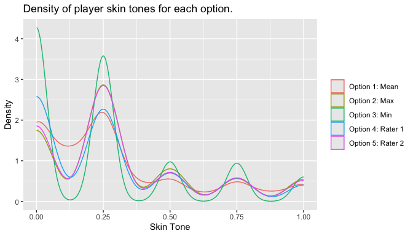

```r
branched |>
  ggplot(mapping = aes(x = skin_tone, color = universe)) +
  geom_density(alpha = 0.2) +
  labs(title = "Density of player skin tones for each option.",
       x = "Skin Tone", y = "Density") +
  scale_color_discrete(
    labels = c("Option 1: Mean",
               "Option 2: Max",
               "Option 3: Min",
               "Option 4: Rater 1",
               "Option 5: Rater 2"),
    name = NULL
  )
```

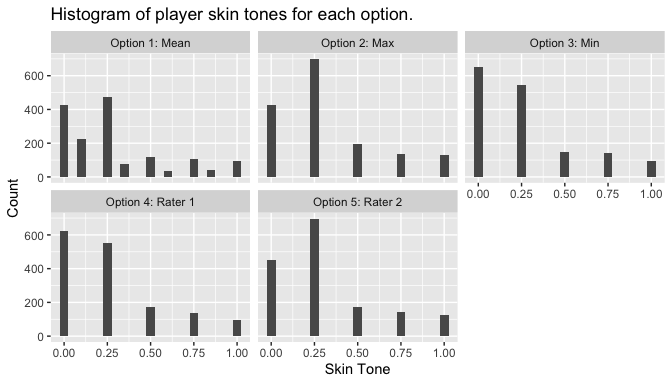

```r
branched |>
  ggplot(mapping = aes(x = skin_tone)) +
  geom_histogram(position = "dodge", bins = 21) +
  labs(title = "Histogram of player skin tones for each option.",
       y = "Count", x = "Skin Tone") +
  facet_wrap(
    . ~ universe,
    labeller = labeller(
      universe = c(`1` = "Option 1: Mean",
                   `2` = "Option 2: Max",
                   `3` = "Option 3: Min",
                   `4` = "Option 4: Rater 1",
                   `5` = "Option 5: Rater 2")
    )
  )
```

## References

Silberzahn, Raphael, Eric Luis Uhlmann, Dan Martin, Pasquale Anselmi, Frederik Aust, Eli C. Awtrey, Štěpán Bahník, et al. 2014. “Many Analysts, One Dataset: Making Transparent How Variations in Anlytical Choices Affect Results.” https://osf.io/gvm2z/.